# val-6-models

# Introduction

Model metrics for validation set 6. Note that these metrics include internal and external validation. I have run internal and external validation over 10 iterations of 10 fold cross-validation. E.g. In my first training instance, I have trained a model on folds 2-10, then tested on fold 1 (internal validation) and on validation set 6 (external validation). I then repeated for the rest of the folds and remaining 9 iterations. Thus, I should have 10 predictions for each sample in the training set. The external validation should have more - 100 predictions for each sample in the ext-val set.

Please note that the confusion matrices are of 10 iterations of 10 fold cross validation. I.e. for internal 10-fold cross validation, we should have 10*65=650 predictions - 10 predictions for each sample in the training set since we have 10 iterations. For external validation, we should have 10*10*10=1000 predictions - 10 iterations and 10 folds for 10 patients in the validation set. The numbers of patients in each confusion matrix should sum to their respective values that are listed.

# model= ridge filter= 0.05 outcome= hCG clin feat= none

## Internal validation

|  | Accuracy | Sensitivity | Specificity | AUC |
| --- | --- | --- | --- | --- |
| metric.mean.df | 0.786 | 0.822 | 0.752 | 0.874 |
| metric.quantiles | (0.754-0.815) | (0.781-0.868) | (0.704-0.788) | (0.853-0.897) |

|  | Negative-reference | Positive-reference |
| --- | --- | --- |
| Negative-prediction | 248 | 57 |
| Positive-prediction | 82 | 263 |

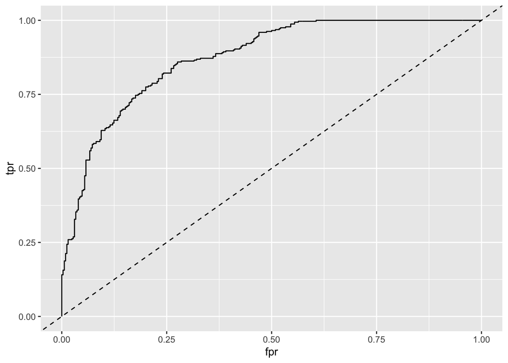

## External validation

|  | Accuracy | Sensitivity | Specificity | AUC |
| --- | --- | --- | --- | --- |
| metric.mean.df | 0.677 | 0.623 | 0.758 | 0.812 |
| metric.quantiles | (0.662-0.69) | (0.587-0.65) | (0.75-0.794) | (0.806-0.818) |

|  | Negative-reference | Positive-reference |
| --- | --- | --- |
| Negative-prediction | 303 | 226 |
| Positive-prediction | 97 | 374 |

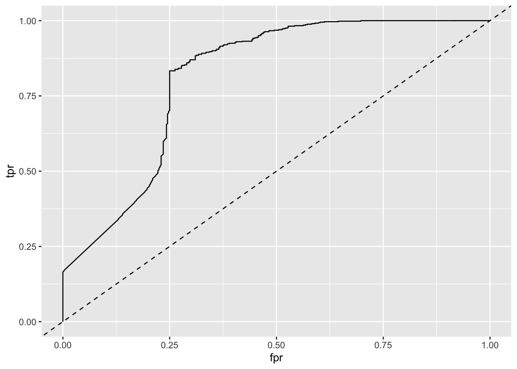

# model= ridge filter= 0.05 outcome= hCG clin feat= age

## Internal validation

|  | Accuracy | Sensitivity | Specificity | AUC |
| --- | --- | --- | --- | --- |
| metric.mean.df | 0.802 | 0.822 | 0.782 | 0.879 |
| metric.quantiles | (0.785-0.827) | (0.788-0.844) | (0.734-0.818) | (0.861-0.899) |

|  | Negative-reference | Positive-reference |
| --- | --- | --- |
| Negative-prediction | 258 | 57 |
| Positive-prediction | 72 | 263 |

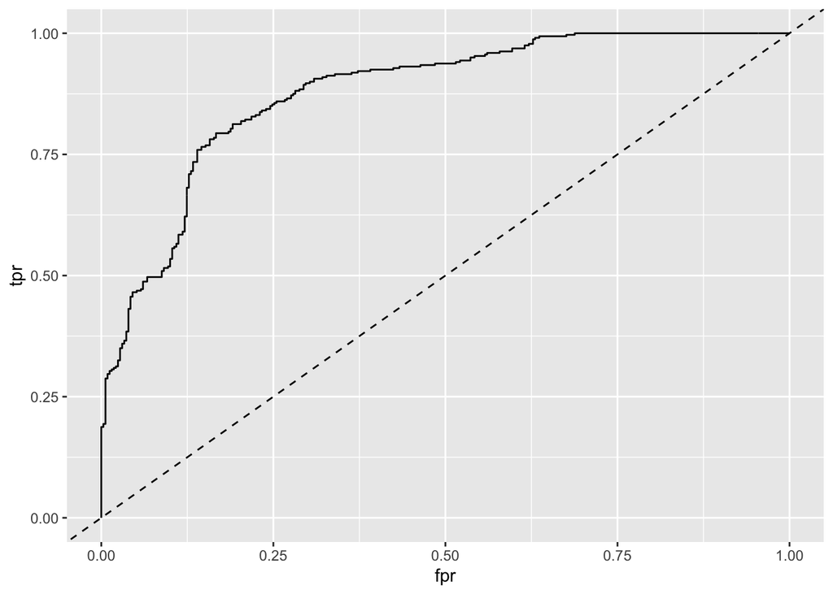

## External validation

|  | Accuracy | Sensitivity | Specificity | AUC |
| --- | --- | --- | --- | --- |
| metric.mean.df | 0.646 | 0.572 | 0.758 | 0.806 |
| metric.quantiles | (0.625-0.66) | (0.537-0.583) | (0.75-0.775) | (0.8-0.811) |

|  | Negative-reference | Positive-reference |
| --- | --- | --- |
| Negative-prediction | 303 | 257 |
| Positive-prediction | 97 | 343 |

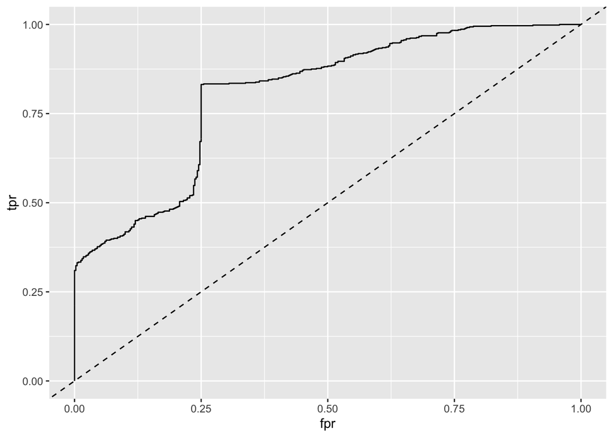

# model= ridge filter= 0.05 outcome= hCG clin feat= g1+g2+g3

## Internal validation

|  | Accuracy | Sensitivity | Specificity | AUC |
| --- | --- | --- | --- | --- |
| metric.mean.df | 0.743 | 0.741 | 0.745 | 0.841 |
| metric.quantiles | (0.708-0.769) | (0.688-0.781) | (0.704-0.788) | (0.811-0.87) |

|  | Negative-reference | Positive-reference |
| --- | --- | --- |
| Negative-prediction | 246 | 83 |
| Positive-prediction | 84 | 237 |

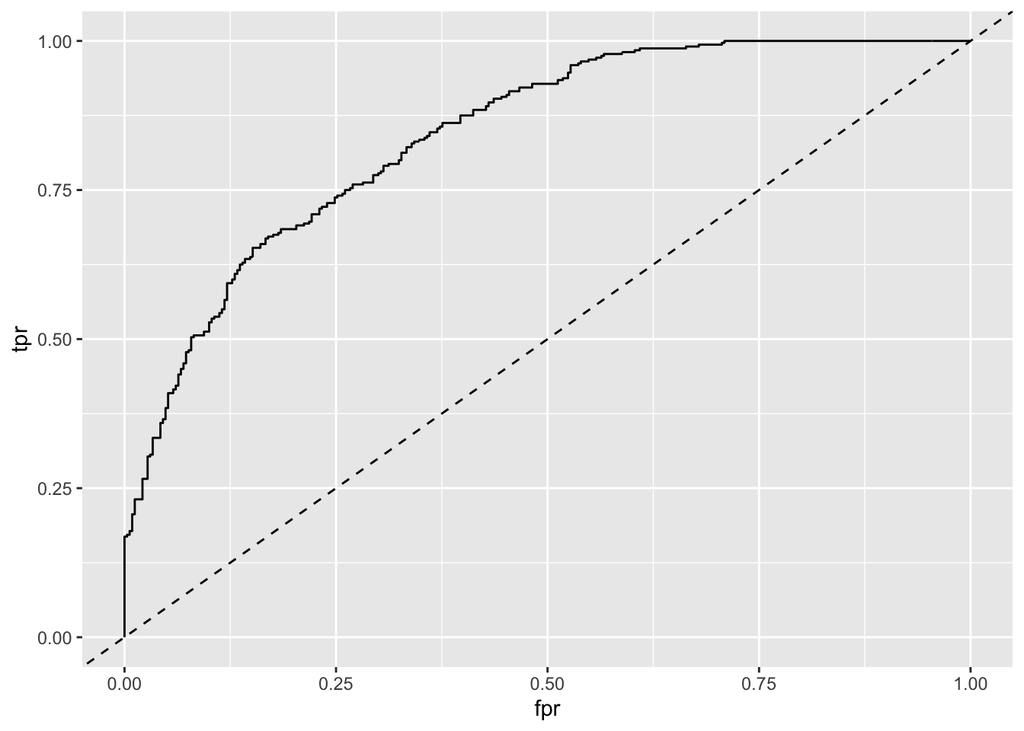

## External validation

|  | Accuracy | Sensitivity | Specificity | AUC |
| --- | --- | --- | --- | --- |
| metric.mean.df | 0.69 | 0.65 | 0.75 | 0.841 |
| metric.quantiles | (0.67-0.7) | (0.617-0.667) | (0.75-0.75) | (0.829-0.851) |

|  | Negative-reference | Positive-reference |
| --- | --- | --- |
| Negative-prediction | 300 | 210 |
| Positive-prediction | 100 | 390 |

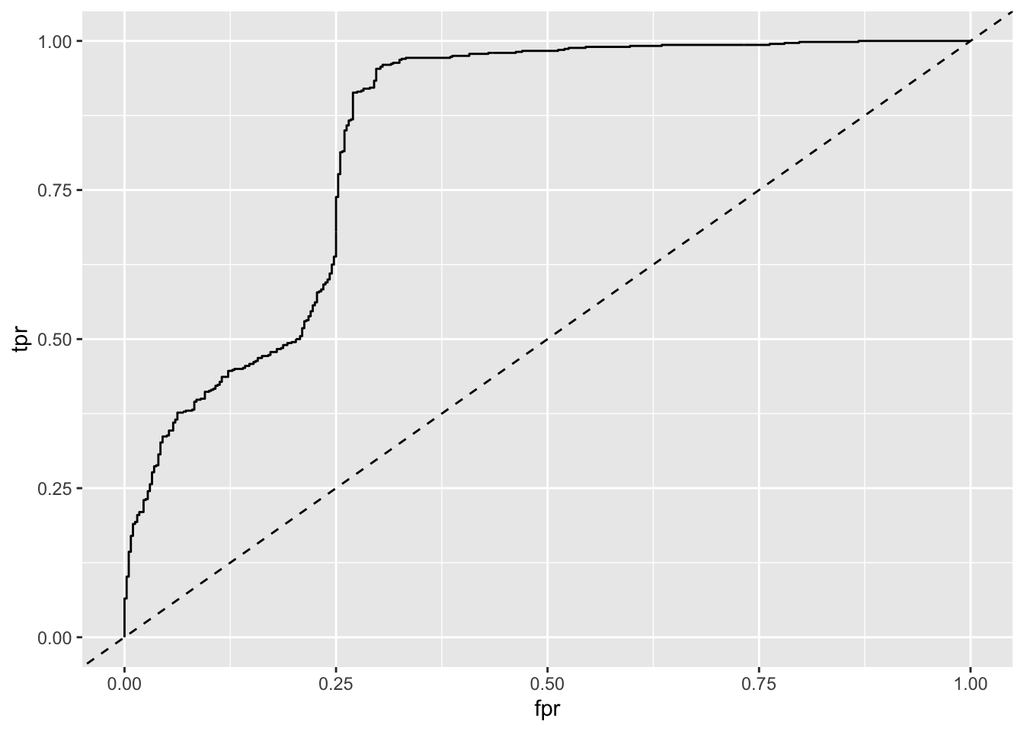

# model= ridge filter= 0.05 outcome= hCG clin feat= g1+g2+g3+age

## Internal validation

|  | Accuracy | Sensitivity | Specificity | AUC |
| --- | --- | --- | --- | --- |
| metric.mean.df | 0.772 | 0.778 | 0.767 | 0.852 |
| metric.quantiles | (0.727-0.812) | (0.726-0.837) | (0.704-0.811) | (0.816-0.878) |

|  | Negative-reference | Positive-reference |
| --- | --- | --- |
| Negative-prediction | 253 | 71 |
| Positive-prediction | 77 | 249 |

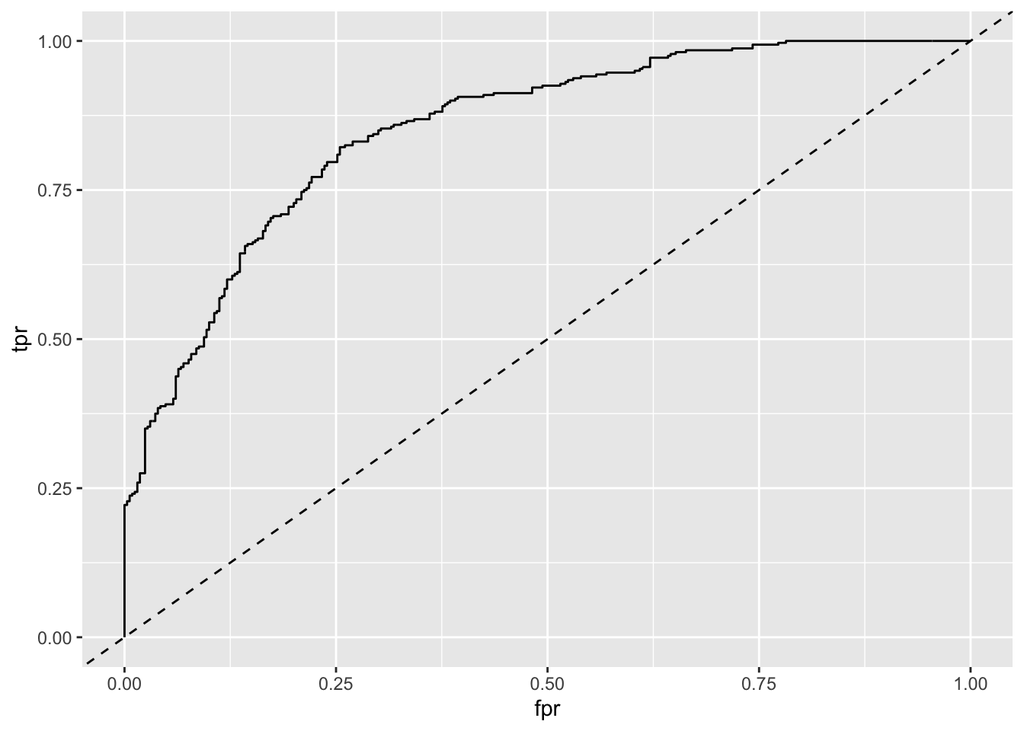

## External validation

|  | Accuracy | Sensitivity | Specificity | AUC |
| --- | --- | --- | --- | --- |
| metric.mean.df | 0.674 | 0.623 | 0.75 | 0.809 |
| metric.quantiles | (0.66-0.696) | (0.6-0.659) | (0.75-0.75) | (0.801-0.823) |

|  | Negative-reference | Positive-reference |
| --- | --- | --- |
| Negative-prediction | 300 | 226 |
| Positive-prediction | 100 | 374 |

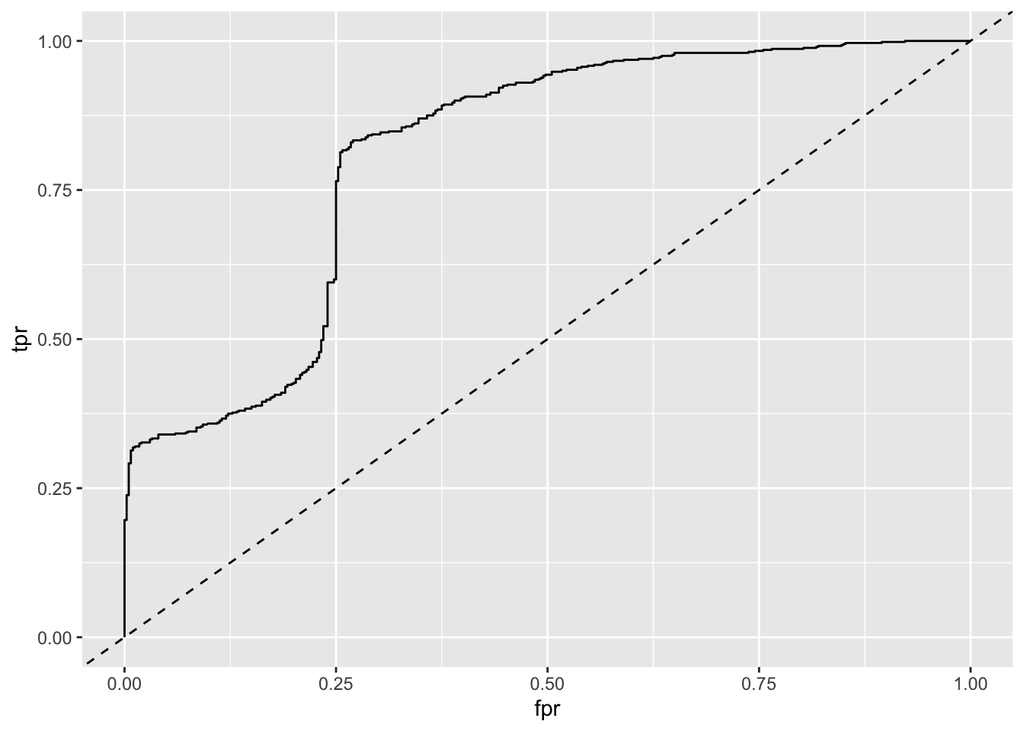

# model= ridge filter= 0.05 outcome= hCG clin feat= g3

## Internal validation

|  | Accuracy | Sensitivity | Specificity | AUC |
| --- | --- | --- | --- | --- |
| metric.mean.df | 0.766 | 0.794 | 0.739 | 0.858 |
| metric.quantiles | (0.754-0.785) | (0.781-0.812) | (0.704-0.758) | (0.836-0.879) |

|  | Negative-reference | Positive-reference |
| --- | --- | --- |
| Negative-prediction | 244 | 66 |
| Positive-prediction | 86 | 254 |

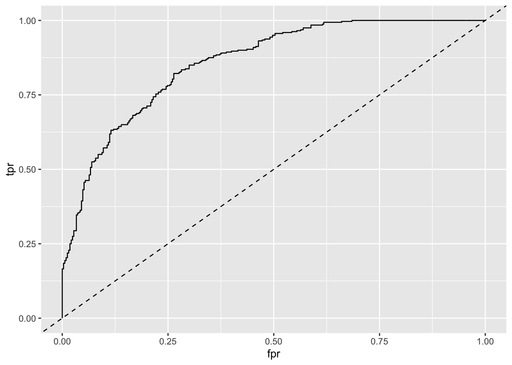

## External validation

|  | Accuracy | Sensitivity | Specificity | AUC |
| --- | --- | --- | --- | --- |
| metric.mean.df | 0.72 | 0.7 | 0.75 | 0.779 |
| metric.quantiles | (0.71-0.73) | (0.683-0.717) | (0.75-0.75) | (0.77-0.789) |

|  | Negative-reference | Positive-reference |
| --- | --- | --- |
| Negative-prediction | 300 | 180 |
| Positive-prediction | 100 | 420 |

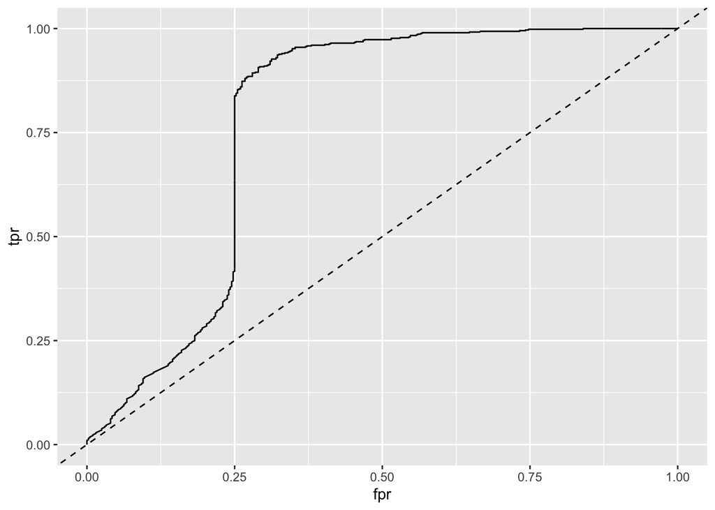

# model= ridge filter= 0.05 outcome= hCG clin feat= g3+age

## Internal validation

|  | Accuracy | Sensitivity | Specificity | AUC |
| --- | --- | --- | --- | --- |
| metric.mean.df | 0.788 | 0.822 | 0.755 | 0.865 |
| metric.quantiles | (0.745-0.812) | (0.764-0.844) | (0.727-0.788) | (0.839-0.881) |

|  | Negative-reference | Positive-reference |
| --- | --- | --- |
| Negative-prediction | 249 | 57 |
| Positive-prediction | 81 | 263 |

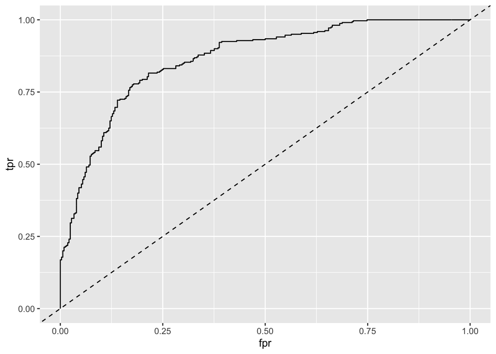

## External validation

|  | Accuracy | Sensitivity | Specificity | AUC |
| --- | --- | --- | --- | --- |
| metric.mean.df | 0.682 | 0.637 | 0.75 | 0.774 |
| metric.quantiles | (0.67-0.698) | (0.617-0.663) | (0.75-0.75) | (0.766-0.783) |

|  | Negative-reference | Positive-reference |
| --- | --- | --- |
| Negative-prediction | 300 | 218 |
| Positive-prediction | 100 | 382 |

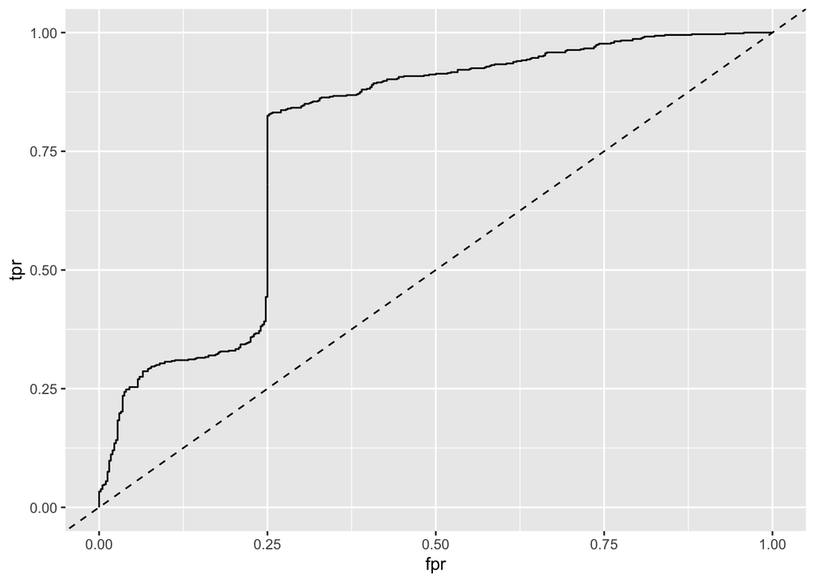

# model= ridge filter= 0.1 outcome= hCG clin feat= none

## Internal validation

|  | Accuracy | Sensitivity | Specificity | AUC |
| --- | --- | --- | --- | --- |
| metric.mean.df | 0.798 | 0.794 | 0.803 | 0.876 |
| metric.quantiles | (0.761-0.855) | (0.733-0.844) | (0.788-0.865) | (0.863-0.891) |

|  | Negative-reference | Positive-reference |
| --- | --- | --- |
| Negative-prediction | 265 | 66 |
| Positive-prediction | 65 | 254 |

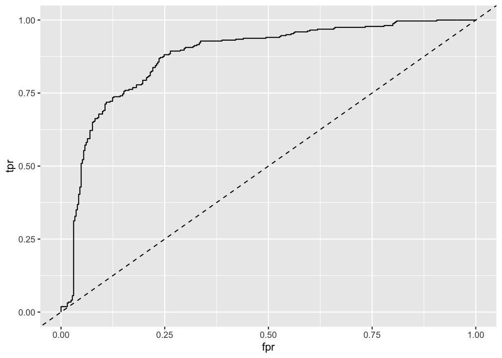

## External validation

|  | Accuracy | Sensitivity | Specificity | AUC |
| --- | --- | --- | --- | --- |
| metric.mean.df | 0.713 | 0.835 | 0.53 | 0.744 |
| metric.quantiles | (0.702-0.72) | (0.833-0.846) | (0.506-0.55) | (0.738-0.752) |

|  | Negative-reference | Positive-reference |
| --- | --- | --- |
| Negative-prediction | 212 | 99 |
| Positive-prediction | 188 | 501 |

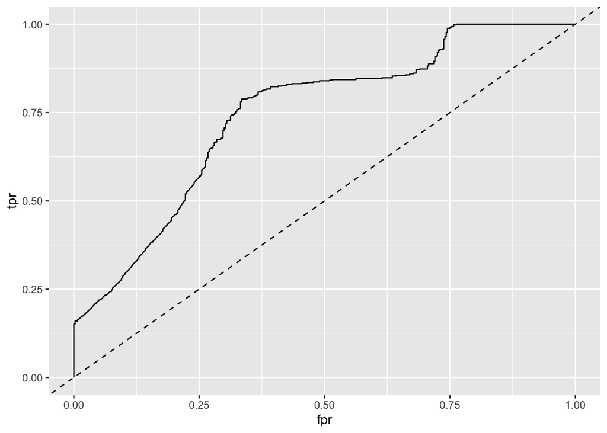

# model= ridge filter= 0.1 outcome= hCG clin feat= age

## Internal validation

|  | Accuracy | Sensitivity | Specificity | AUC |
| --- | --- | --- | --- | --- |
| metric.mean.df | 0.782 | 0.775 | 0.788 | 0.869 |
| metric.quantiles | (0.757-0.8) | (0.75-0.781) | (0.758-0.818) | (0.847-0.89) |

|  | Negative-reference | Positive-reference |
| --- | --- | --- |
| Negative-prediction | 260 | 72 |
| Positive-prediction | 70 | 248 |

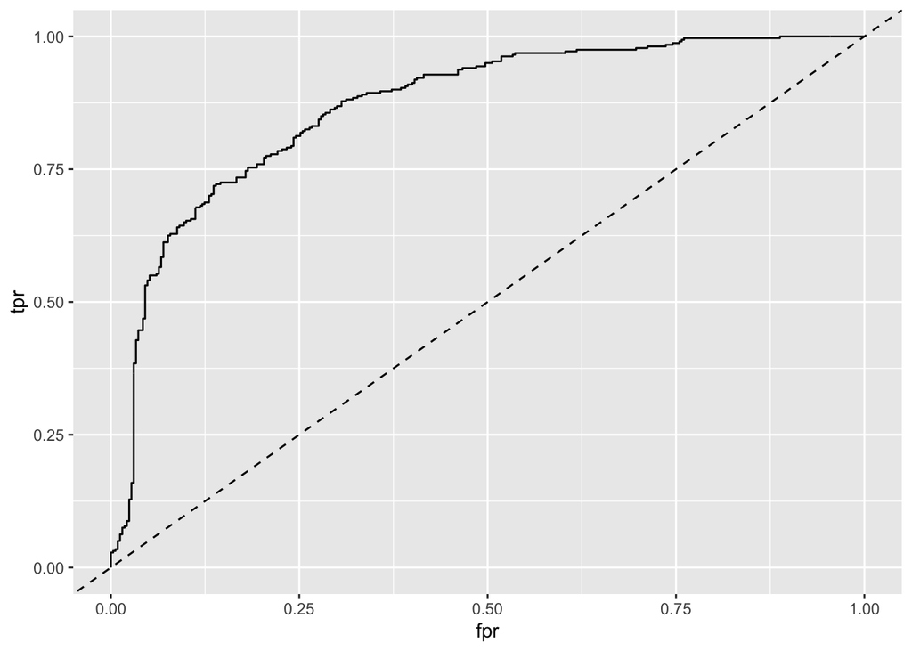

## External validation

|  | Accuracy | Sensitivity | Specificity | AUC |
| --- | --- | --- | --- | --- |
| metric.mean.df | 0.696 | 0.825 | 0.503 | 0.701 |
| metric.quantiles | (0.682-0.708) | (0.804-0.833) | (0.5-0.519) | (0.695-0.71) |

|  | Negative-reference | Positive-reference |
| --- | --- | --- |
| Negative-prediction | 201 | 105 |
| Positive-prediction | 199 | 495 |

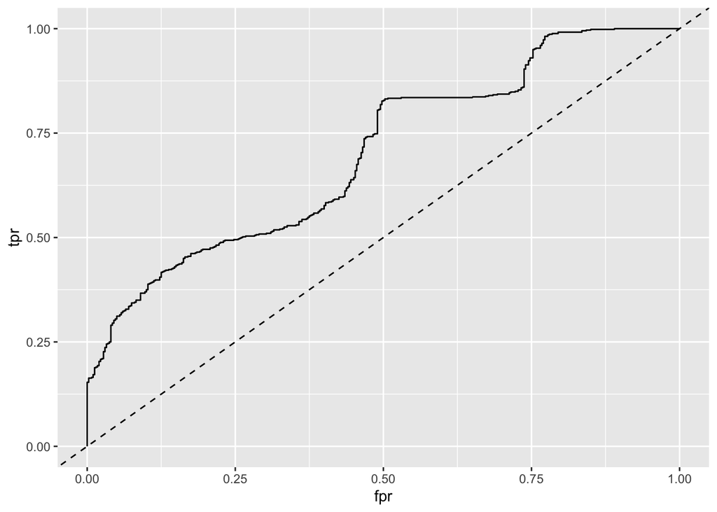

# model= ridge filter= 0.1 outcome= hCG clin feat= g1+g2+g3

## Internal validation

|  | Accuracy | Sensitivity | Specificity | AUC |
| --- | --- | --- | --- | --- |
| metric.mean.df | 0.809 | 0.812 | 0.806 | 0.859 |
| metric.quantiles | (0.776-0.831) | (0.757-0.844) | (0.788-0.818) | (0.845-0.871) |

|  | Negative-reference | Positive-reference |
| --- | --- | --- |
| Negative-prediction | 266 | 60 |
| Positive-prediction | 64 | 260 |

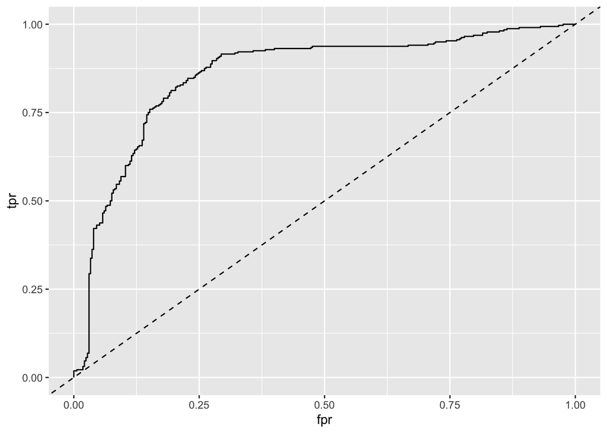

## External validation

|  | Accuracy | Sensitivity | Specificity | AUC |
| --- | --- | --- | --- | --- |
| metric.mean.df | 0.746 | 0.86 | 0.575 | 0.811 |
| metric.quantiles | (0.73-0.76) | (0.85-0.883) | (0.531-0.625) | (0.807-0.814) |

|  | Negative-reference | Positive-reference |
| --- | --- | --- |
| Negative-prediction | 230 | 84 |
| Positive-prediction | 170 | 516 |

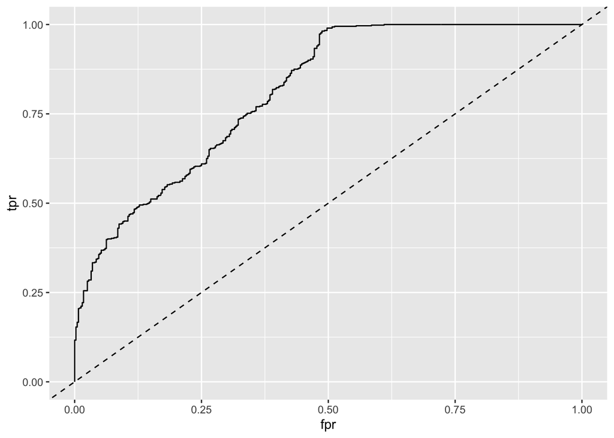

# model= ridge filter= 0.1 outcome= hCG clin feat= g1+g2+g3+age

## Internal validation

|  | Accuracy | Sensitivity | Specificity | AUC |
| --- | --- | --- | --- | --- |
| metric.mean.df | 0.789 | 0.791 | 0.788 | 0.855 |
| metric.quantiles | (0.757-0.815) | (0.757-0.812) | (0.758-0.818) | (0.832-0.876) |

|  | Negative-reference | Positive-reference |
| --- | --- | --- |
| Negative-prediction | 260 | 67 |
| Positive-prediction | 70 | 253 |

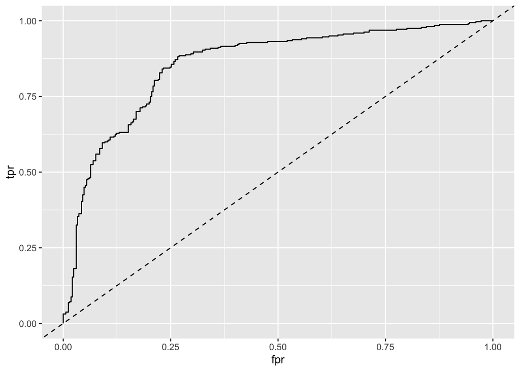

## External validation

|  | Accuracy | Sensitivity | Specificity | AUC |
| --- | --- | --- | --- | --- |
| metric.mean.df | 0.718 | 0.853 | 0.515 | 0.766 |
| metric.quantiles | (0.702-0.73) | (0.833-0.867) | (0.5-0.525) | (0.756-0.776) |

|  | Negative-reference | Positive-reference |
| --- | --- | --- |
| Negative-prediction | 206 | 88 |
| Positive-prediction | 194 | 512 |

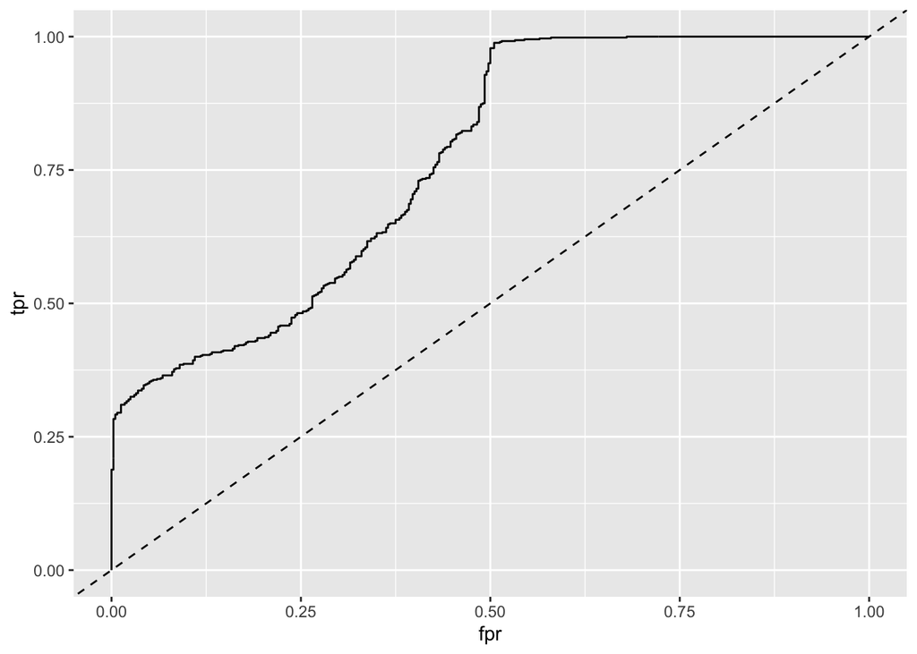

# model= ridge filter= 0.1 outcome= hCG clin feat= g3

## Internal validation

|  | Accuracy | Sensitivity | Specificity | AUC |
| --- | --- | --- | --- | --- |
| metric.mean.df | 0.814 | 0.812 | 0.815 | 0.867 |
| metric.quantiles | (0.776-0.843) | (0.757-0.844) | (0.788-0.848) | (0.852-0.878) |

|  | Negative-reference | Positive-reference |
| --- | --- | --- |
| Negative-prediction | 269 | 60 |
| Positive-prediction | 61 | 260 |

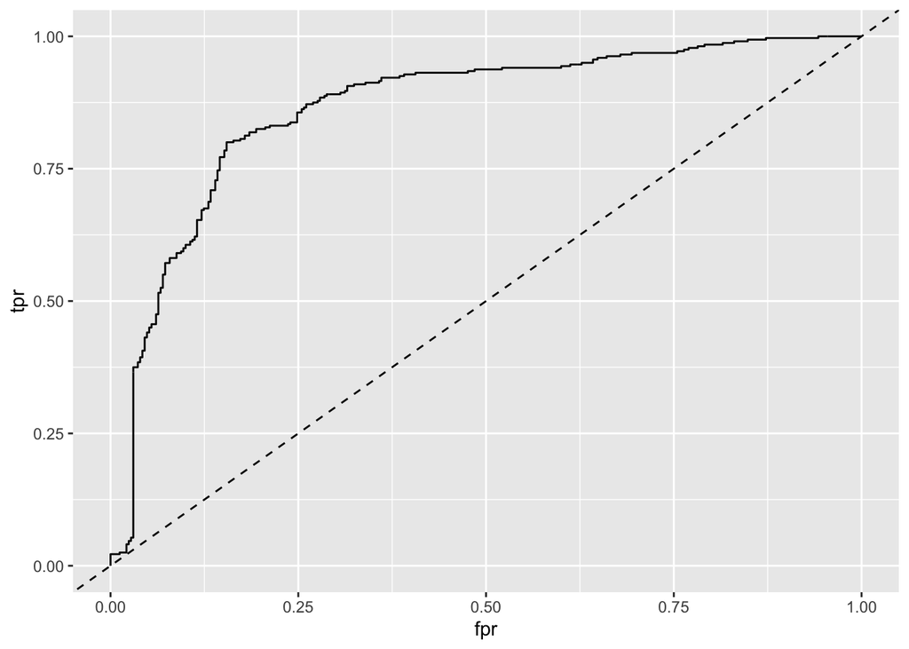

## External validation

|  | Accuracy | Sensitivity | Specificity | AUC |
| --- | --- | --- | --- | --- |
| metric.mean.df | 0.726 | 0.865 | 0.518 | 0.71 |
| metric.quantiles | (0.712-0.738) | (0.85-0.883) | (0.5-0.525) | (0.703-0.717) |

|  | Negative-reference | Positive-reference |
| --- | --- | --- |
| Negative-prediction | 207 | 81 |
| Positive-prediction | 193 | 519 |

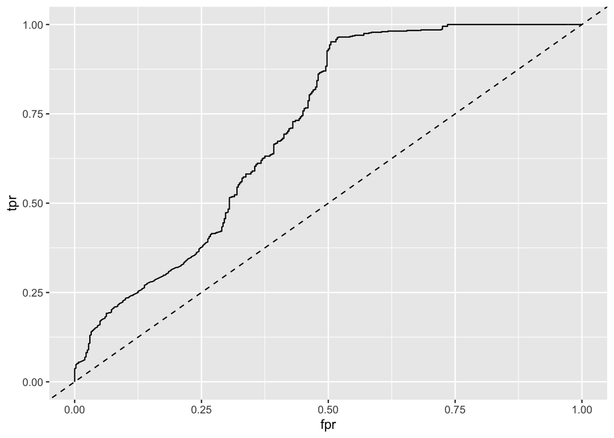

# model= ridge filter= 0.1 outcome= hCG clin feat= g3+age

## Internal validation

|  | Accuracy | Sensitivity | Specificity | AUC |
| --- | --- | --- | --- | --- |
| metric.mean.df | 0.809 | 0.797 | 0.821 | 0.86 |
| metric.quantiles | (0.785-0.843) | (0.75-0.844) | (0.788-0.848) | (0.842-0.876) |

|  | Negative-reference | Positive-reference |
| --- | --- | --- |
| Negative-prediction | 271 | 65 |
| Positive-prediction | 59 | 255 |

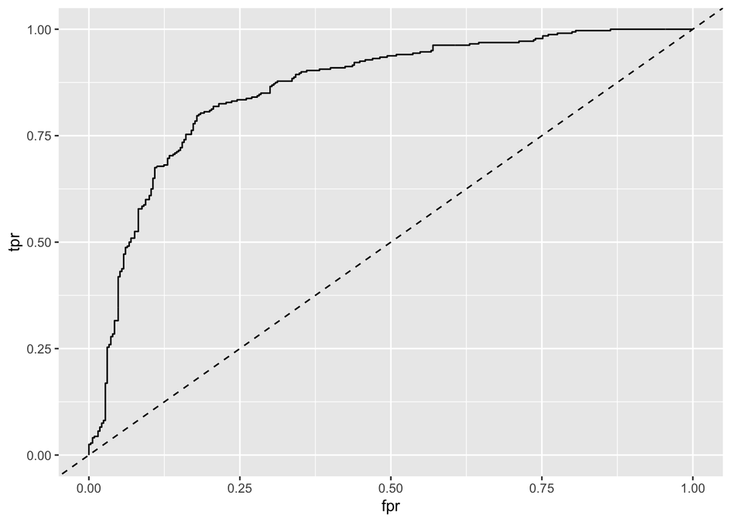

## External validation

|  | Accuracy | Sensitivity | Specificity | AUC |
| --- | --- | --- | --- | --- |
| metric.mean.df | 0.698 | 0.83 | 0.5 | 0.673 |
| metric.quantiles | (0.69-0.718) | (0.817-0.863) | (0.5-0.5) | (0.665-0.681) |

|  | Negative-reference | Positive-reference |
| --- | --- | --- |
| Negative-prediction | 200 | 102 |
| Positive-prediction | 200 | 498 |

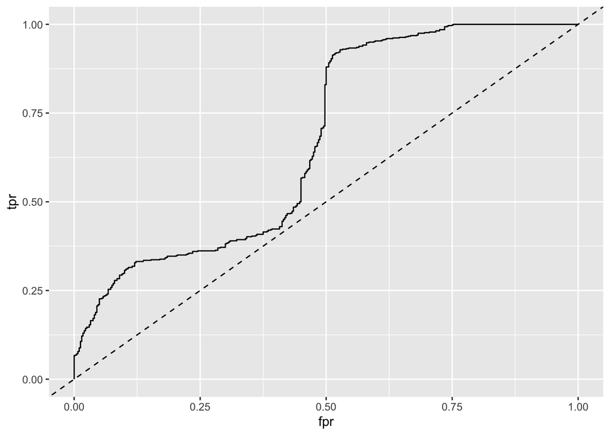

# model= ridge filter= 0.05 outcome= lbo clin feat= none

## Internal validation

|  | Accuracy | Sensitivity | Specificity | AUC |
| --- | --- | --- | --- | --- |
| metric.mean.df | 0.749 | 0.615 | 0.838 | 0.814 |
| metric.quantiles | (0.699-0.793) | (0.517-0.684) | (0.781-0.872) | (0.771-0.84) |

|  | NPO-reference | Live_birth-reference |
| --- | --- | --- |
| NPO-prediction | 327 | 100 |
| Live_birth-prediction | 63 | 160 |

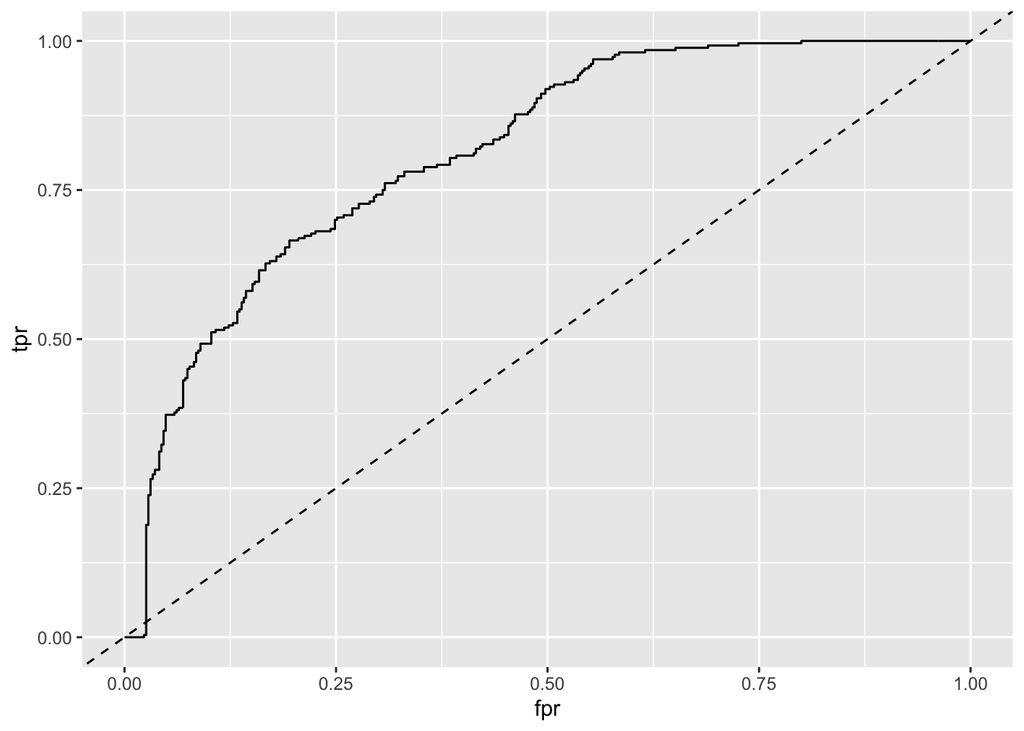

## External validation

|  | Accuracy | Sensitivity | Specificity | AUC |
| --- | --- | --- | --- | --- |
| metric.mean.df | 0.66 | 0.595 | 0.758 | 0.737 |
| metric.quantiles | (0.65-0.688) | (0.57-0.633) | (0.75-0.775) | (0.728-0.749) |

|  | NPO-reference | Live_birth-reference |
| --- | --- | --- |
| NPO-prediction | 303 | 243 |
| Live_birth-prediction | 97 | 357 |

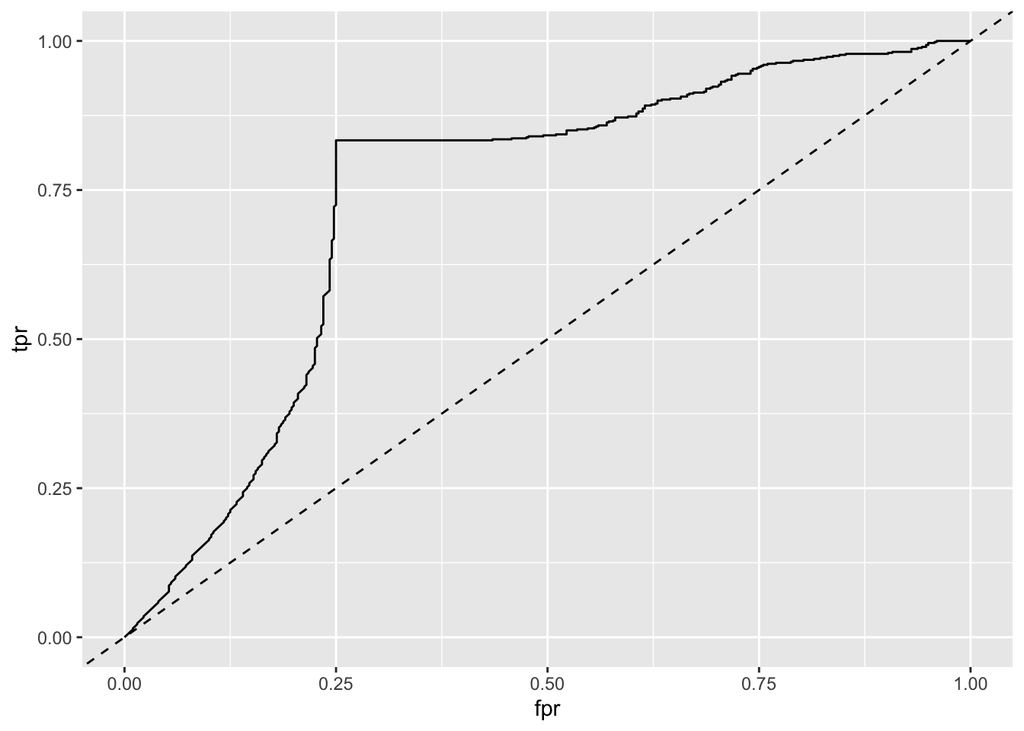

# model= ridge filter= 0.05 outcome= lbo clin feat= age

## Internal validation

|  | Accuracy | Sensitivity | Specificity | AUC |
| --- | --- | --- | --- | --- |
| metric.mean.df | 0.729 | 0.588 | 0.823 | 0.817 |
| metric.quantiles | (0.68-0.769) | (0.509-0.645) | (0.755-0.872) | (0.781-0.844) |

|  | NPO-reference | Live_birth-reference |
| --- | --- | --- |
| NPO-prediction | 321 | 107 |
| Live_birth-prediction | 69 | 153 |

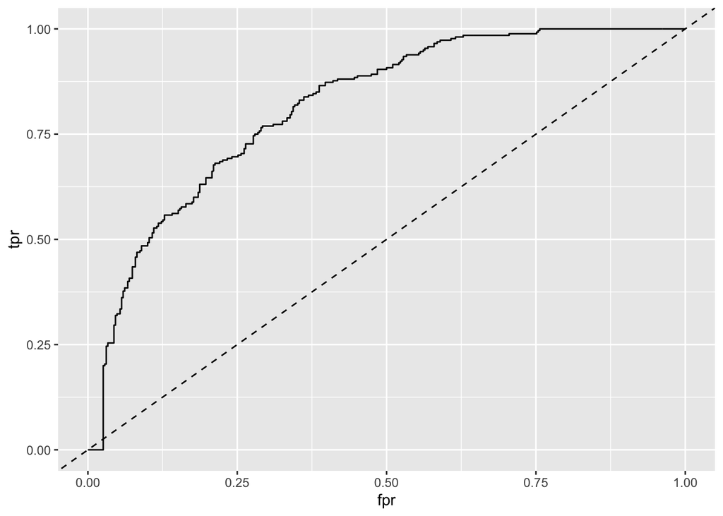

## External validation

|  | Accuracy | Sensitivity | Specificity | AUC |
| --- | --- | --- | --- | --- |
| metric.mean.df | 0.649 | 0.572 | 0.765 | 0.743 |
| metric.quantiles | (0.632-0.66) | (0.55-0.596) | (0.75-0.794) | (0.736-0.75) |

|  | NPO-reference | Live_birth-reference |
| --- | --- | --- |
| NPO-prediction | 306 | 257 |
| Live_birth-prediction | 94 | 343 |

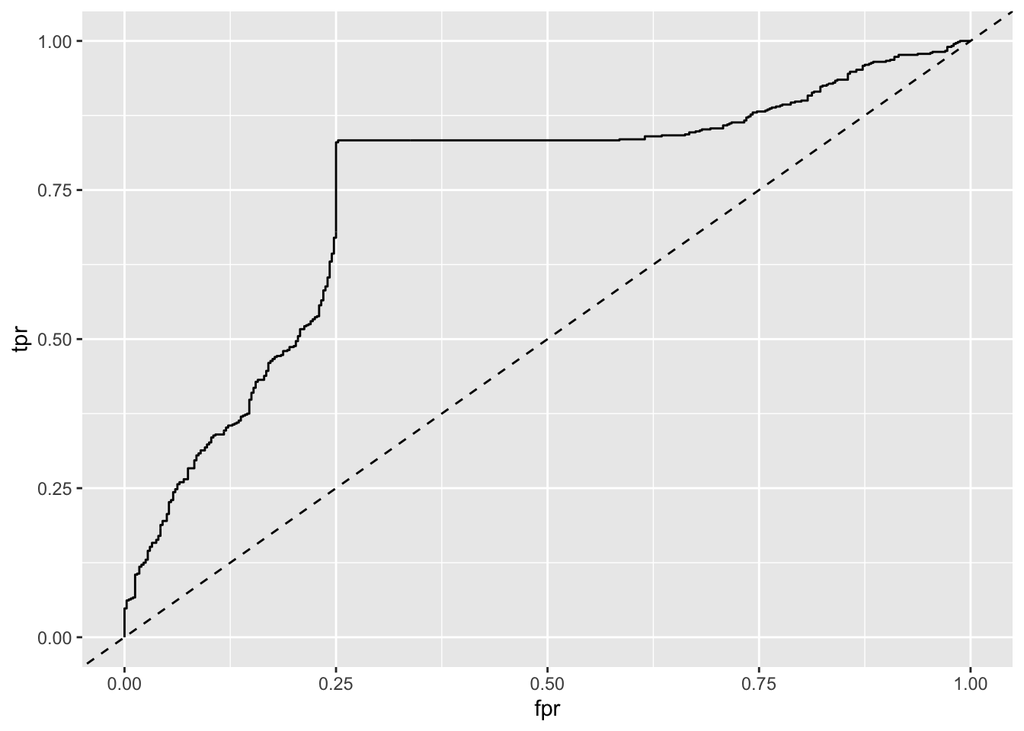

# model= ridge filter= 0.05 outcome= lbo clin feat= g1+g2+g3

## Internal validation

|  | Accuracy | Sensitivity | Specificity | AUC |
| --- | --- | --- | --- | --- |
| metric.mean.df | 0.749 | 0.623 | 0.833 | 0.83 |
| metric.quantiles | (0.711-0.785) | (0.577-0.684) | (0.795-0.866) | (0.803-0.858) |

|  | NPO-reference | Live_birth-reference |
| --- | --- | --- |
| NPO-prediction | 325 | 98 |
| Live_birth-prediction | 65 | 162 |

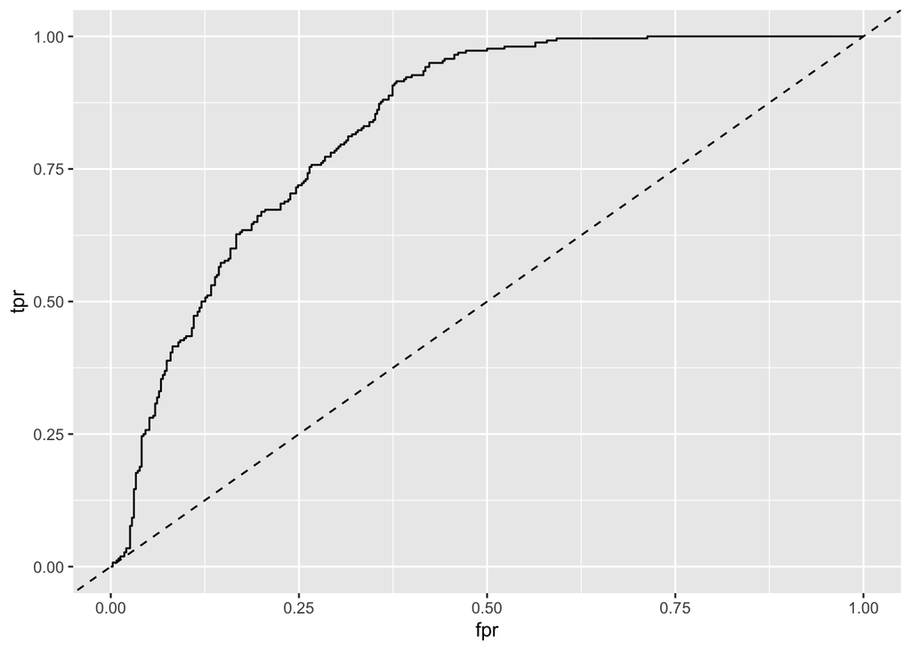

## External validation

|  | Accuracy | Sensitivity | Specificity | AUC |
| --- | --- | --- | --- | --- |
| metric.mean.df | 0.529 | 0.382 | 0.75 | 0.733 |
| metric.quantiles | (0.51-0.548) | (0.35-0.413) | (0.75-0.75) | (0.728-0.739) |

|  | NPO-reference | Live_birth-reference |
| --- | --- | --- |
| NPO-prediction | 300 | 371 |
| Live_birth-prediction | 100 | 229 |

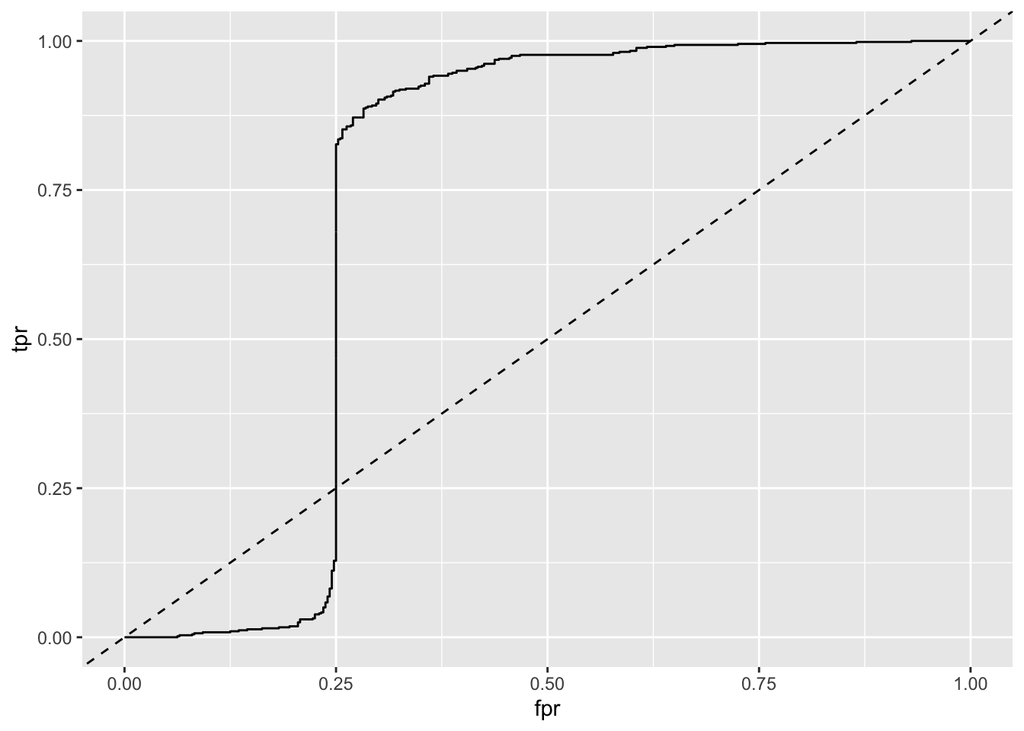

# model= ridge filter= 0.05 outcome= lbo clin feat= g1+g2+g3+age

## Internal validation

|  | Accuracy | Sensitivity | Specificity | AUC |
| --- | --- | --- | --- | --- |
| metric.mean.df | 0.74 | 0.604 | 0.831 | 0.833 |
| metric.quantiles | (0.708-0.769) | (0.577-0.645) | (0.795-0.866) | (0.801-0.857) |

|  | NPO-reference | Live_birth-reference |
| --- | --- | --- |
| NPO-prediction | 324 | 103 |
| Live_birth-prediction | 66 | 157 |

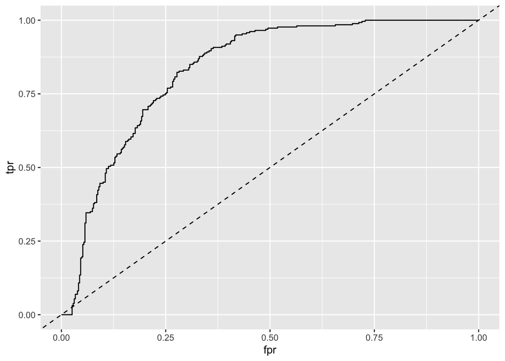

## External validation

|  | Accuracy | Sensitivity | Specificity | AUC |
| --- | --- | --- | --- | --- |
| metric.mean.df | 0.54 | 0.4 | 0.75 | 0.715 |
| metric.quantiles | (0.522-0.558) | (0.37-0.43) | (0.75-0.75) | (0.71-0.72) |

|  | NPO-reference | Live_birth-reference |
| --- | --- | --- |
| NPO-prediction | 300 | 360 |
| Live_birth-prediction | 100 | 240 |

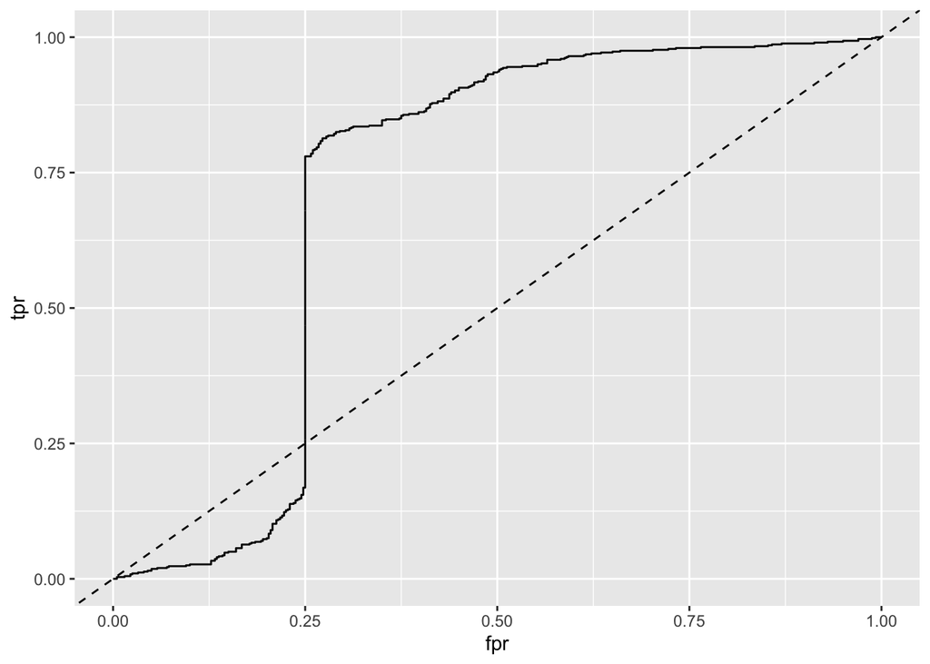